# Actividad N°5 Optimizando la pauta digital

**Integrantes**

- Juan David Rivera Builes
- Gustavo Rendon Vélez
- Sandra Milena Berrio Berrio
- Veronica Yohana Garzón Zuluaga

**Objetivo**

La plataforma digital de servicios QUIX quiere atraer más usuarios. Para ello invertirá en pauta digital. La pauta digital permite configurar las horas en la que las diferentes redes sociales le mostrarán los anuncios de la plataforma a los potenciales usuarios.

## Planteamiento del problema

Antes de realizar en análisis, buscamos contextualizarnos sobre la plataforma digital de servicios **QUIX**, entendiendo los objetivos y aspiraciones de la compañia, con el fin de enfocar los análisis hacia ellos.

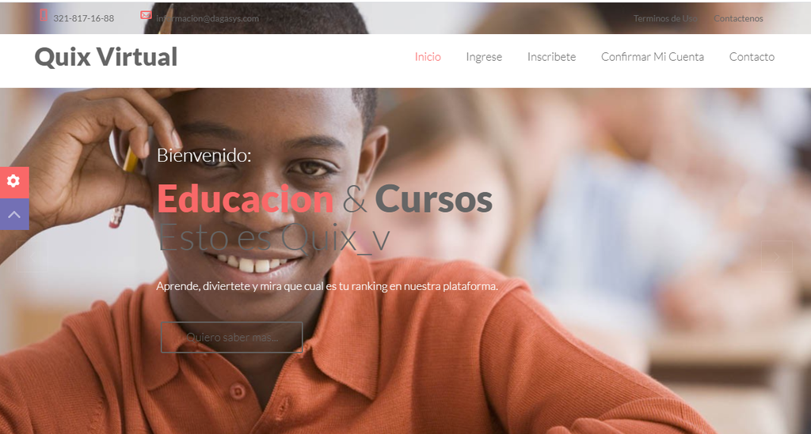

La plataforma de servicios QUIX se encarga de ofertar cursos a personas de diversas edades. Entendiendo esto buscamos entonces, a partir de la información recogida de las conexiones de usuarios en las redes sociales para periodo de tiempo, identificar el momento optimo de realizar la pauta de la plataforma.

A continuación , realizaremos un analisis de los datos (*en python*) recolectados para encontrar el o los momentos optimos para presentar la pauta y así distribuir de manera optima los recursos destinados para esta.

## Análisis

Leemos las librerías necesarias

```python
import pandas as pd
import os
import matplotlib.pyplot as plt
import seaborn as sb
import numpy as np
```

Realizamos la conexión con *Drive* ya que allí se encuentra la información y procedemos a su lectura

```python
from google.colab import drive
drive.mount('/content/drive')
```

```python
!ls '/content/drive/Shareddrives/Decisiones Bajo Incertidumbre/05.Optimizando la pauta Digital'
```

```
'Actividad_05.Optimizar la Pauta.ipynb'
 datos_horas_conexion.csv
 Sandra_Actividad_05_Optimizar_la_Pauta.ipynb
 Vero_Actividad_05_Optimizar_la_Pauta.ipynb
```

```python
# Leemos la base de datos
path = '/content/drive/Shareddrives/Decisiones Bajo Incertidumbre/05.Optimizando la pauta Digital'
data = pd.read_csv(path + '/datos_horas_conexion.csv', sep=";",decimal=",")
print(" Se leyeron los Datos  ")
print( "Número de filas: "+str(data.shape[0]))
print("Número de columnas: "+str(data.shape[1]))
```

```
 Se leyeron los Datos
Número de filas: 4022
Número de columnas: 5
```

Observamos que la base de datos contienen 4022 registros. Cada registro corresponde al inicio de sesión de un usuario en las redes sociales. A continuació vemos la estructura de la base.

```python
data.head()
```

|  | id_usuario | Calificadora | Correo | Fecha Consulta | Estado usuario |
| --- | --- | --- | --- | --- | --- |
| 0 | c2290d89dfc4 | Buró de Crédito | gmail.com | 19/01/21 9:20 | ACTIVO |
| 1 | 8d24ef1d52d8 | Buró de Crédito | gmail.com | 19/01/21 8:28 | ACTIVO |
| 2 | a5120d2c47fa | Buró de Crédito | gmail.com | 17/01/21 13:36 | ACTIVO |
| 3 | 5a5d70893606 | Buró de Crédito | edubc.mx | 20/01/21 9:27 | ACTIVO |
| 4 | 4a2082948031 | Buró de Crédito | gmail.com | 21/01/21 14:26 | ACTIVO |

Para facilitar y manejar la convensión utilizada para las tablas en python, eliminamos los espacios y colocamos en minuscula todas las letras de los nombres de las variables

```python
data.columns=[x.lower().replace(" ","_") for x in data.columns.tolist()]
data.head()
```

|  | id_usuario | calificadora | correo | fecha_consulta | estado_usuario |
| --- | --- | --- | --- | --- | --- |
| 0 | c2290d89dfc4 | Buró de Crédito | gmail.com | 19/01/21 9:20 | ACTIVO |
| 1 | 8d24ef1d52d8 | Buró de Crédito | gmail.com | 19/01/21 8:28 | ACTIVO |
| 2 | a5120d2c47fa | Buró de Crédito | gmail.com | 17/01/21 13:36 | ACTIVO |
| 3 | 5a5d70893606 | Buró de Crédito | edubc.mx | 20/01/21 9:27 | ACTIVO |
| 4 | 4a2082948031 | Buró de Crédito | gmail.com | 21/01/21 14:26 | ACTIVO |

### Análisis de la base

A continuación se encuentra una serie de agrupaciones y cálculos de nuevas variables, las cuales permitiran encontrar los momentos optimos para realizar la pauta.

La variable Calificadora por ejemplo contiene el mismo valos para los 4022 registros. No nos brinda información importante

```python
data.groupby('calificadora',as_index=False)["id_usuario"].count().rename(columns={'id_usuario':'Conteo'})
```

|  | calificadora | Conteo |
| --- | --- | --- |
| 0 | Buró de Crédito | 4022 |

En cuanto a los correos, se cuentran 93 tipos de dominios diferentes, pero se evidencia que algunos se eucuentran mal escritos. Además no se observa que puedan generar información para encontrar el momento optimo de la pauta por lo que se decide no utilizar la variable en el estudio.

```python
data.groupby('correo',as_index=False)["id_usuario"].count().sort_values('id_usuario',ascending=False).rename(columns={'id_usuario':'Conteo'})
```

|  | correo | Conteo |
| --- | --- | --- |
| 26 | gmail.com | 2812 |
| 47 | hotmail.com | 802 |
| 74 | outlook.com | 111 |
| 60 | live.com.mx | 39 |
| 89 | yahoo.com.mx | 29 |
| ... | ... | ... |
| 29 | gmail.coml | 1 |
| 28 | gmail.comcom | 1 |
| 25 | gmail.co.com | 1 |
| 24 | gmail.Com | 1 |
| 92 | yomax.com.mx | 1 |

93 rows × 2 columns

Se procede entonces a realizar el análisis de la variable fecha*consulta, la cual asumimos que se trata de la hora en que el usuario realiza el logueo a la red social. Se puede observar en el resultado posterio que la variable fue leida con formato de caracter* (object)_ por lo que se construye a partir de la misma una nueva variable en formato fecha lo cual nos permite desintegrar el dato en : año, med, dia, hora, minutos, segundos.

```python
data.dtypes
```

```
id_usuario        object
calificadora      object
correo            object
fecha_consulta    object
estado_usuario    object
dtype: object
```

```python
data["fecha_format"]=pd.to_datetime(data["fecha_consulta"],format="%d/%m/%y %H:%M")
```

```python
data.head()
```

[output not shown]

```python
data.dtypes
```

[output not shown]

```python
data["dia_semana"]=data['fecha_format'].dt.day_name() #dayname
data["year"]=data['fecha_format'].dt.strftime("%Y")  # year
data["month"]=data['fecha_format'].dt.strftime("%m")  # month
data["day"]=data['fecha_format'].dt.strftime("%d")  # day
data["hour"]=data['fecha_format'].dt.hour  # hour
data["minut"]=data['fecha_format'].dt.minute  # minute
```

```python
data.tail()
```

[output not shown]

```python
def moment_Day(hora):
    if hora<=4:
        return "00:00 To 4:00 "
    elif hora<=8:
        return "04:00 To 8:00"
    elif hora<=12:
        return "08:00 To 12:00"
    elif hora<=16:
        return "12:00 To 16:00"
    elif hora<=20:
        return "16:00 To 20:00"
    else:
        return "20:00 To 24:00"
```

```python
data['horario'] = data['hour'].map(moment_Day)
```

```python
data.head()
```

|  | id_usuario | calificadora | correo | fecha_consulta | estado_usuario | fecha_format | dia_semana | year | month | day | hour | minut | horario |
| --- | --- | --- | --- | --- | --- | --- | --- | --- | --- | --- | --- | --- | --- |
| 0 | c2290d89dfc4 | Buró de Crédito | gmail.com | 19/01/21 9:20 | ACTIVO | 2021-01-19 09:20:00 | Tuesday | 2021 | 01 | 19 | 9 | 20 | 08:00 To 12:00 |
| 1 | 8d24ef1d52d8 | Buró de Crédito | gmail.com | 19/01/21 8:28 | ACTIVO | 2021-01-19 08:28:00 | Tuesday | 2021 | 01 | 19 | 8 | 28 | 04:00 To 8:00 |
| 2 | a5120d2c47fa | Buró de Crédito | gmail.com | 17/01/21 13:36 | ACTIVO | 2021-01-17 13:36:00 | Sunday | 2021 | 01 | 17 | 13 | 36 | 12:00 To 16:00 |
| 3 | 5a5d70893606 | Buró de Crédito | edubc.mx | 20/01/21 9:27 | ACTIVO | 2021-01-20 09:27:00 | Wednesday | 2021 | 01 | 20 | 9 | 27 | 08:00 To 12:00 |
| 4 | 4a2082948031 | Buró de Crédito | gmail.com | 21/01/21 14:26 | ACTIVO | 2021-01-21 14:26:00 | Thursday | 2021 | 01 | 21 | 14 | 26 | 12:00 To 16:00 |

## Resultados

A partir de los datos construidos anteriormente buscamos los momentos adecuados para realizar la pauta.

Primero que todo identificaremos el periodo de tiempo y la cantidad de registros que tenemos en cada uno de ellos.

```python
g1=data.groupby(['year','month'],as_index=False)["id_usuario"].count().rename(columns={'id_usuario':'Conteo'})\
         .sort_values(['year','month'],ascending=(True,True))
g1
```

|  | year | month | Conteo |
| --- | --- | --- | --- |
| 0 | 2020 | 12 | 131 |
| 1 | 2021 | 01 | 3891 |

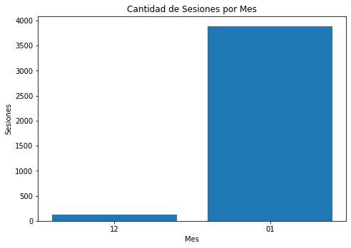

```python
fig = plt.figure()
ax = fig.add_axes([0,0,1,1])
ax.bar(g1["month"],g1["Conteo"])
ax.set_title("Cantidad de Sesiones por Mes")
ax.set_ylabel("Sesiones")
ax.set_xlabel("Mes")
plt.show()
```

Para el ejercicio, con el fin de evitar el posible sesgo por falta de información en el mes de diciembre, no tendremos en cuenta el mes en que se toma la información, suponemos que todo hace parte del mismo mes, y enfocaremos el análisis en el día del mes, el dia de la semana y las horas de cada registro.

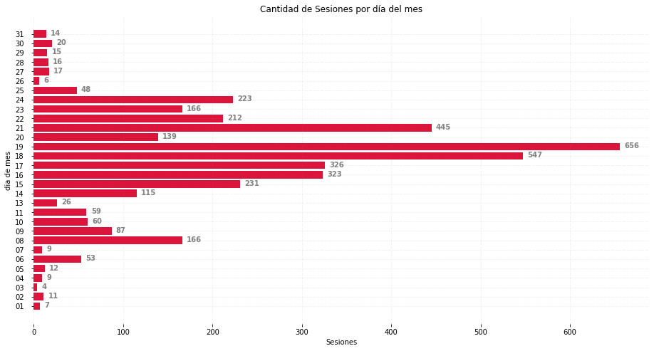

```python
g2=data.groupby(['day'],as_index=False)["id_usuario"].count().rename(columns={'id_usuario':'Conteo'})\
        .sort_values('day',ascending=True)

fig = plt.figure()
ax = fig.add_axes([0,0,2,1.5])
ax.barh(g2["day"],g2["Conteo"],color='crimson')
ax.yaxis.set_tick_params(pad=10)

for s in ['top','bottom','left','right']:
    ax.spines[s].set_visible(False)

for i in ax.patches:
    ax.text(i.get_width()+5, i.get_y()+0.25, str(round((i.get_width()), 2)),
            fontsize=10, fontweight='bold', color='grey')

# Add x,y gridlines
ax.grid(b=True, color='grey', linestyle='-.', linewidth=0.5, alpha=0.2)

ax.set_title("Cantidad de Sesiones por día del mes")
ax.set_ylabel("dia de mes")
ax.set_xlabel("Sesiones")
plt.show()
```

Se evidencia que del día **14** al día **24** (10 días) se tiene el mayor número de sesiones, por lo que se puede concluir que sería esta la franja de días en los cuales se debería hacer la pauta para llegar a más usuarios.

Evaluemos ahora la cantidad de usuario por franja horaria en cada uno de los días de la semana.

```python
table=pd.pivot_table(data,values='id_usuario',index=['horario'],columns=['dia_semana'],aggfunc='count')
table=table[['Monday','Tuesday','Wednesday','Thursday','Friday','Saturday','Sunday']]
table
```

| dia_semana horario | Monday | Tuesday | Wednesday | Thursday | Friday | Saturday | Sunday |
| --- | --- | --- | --- | --- | --- | --- | --- |
| 00:00 To 4:00 | 69 | 78 | 40 | 22 | 61 | 135 | 88 |
| 04:00 To 8:00 | 31 | 70 | 17 | 10 | 31 | 67 | 49 |
| 08:00 To 12:00 | 135 | 137 | 49 | 42 | 126 | 98 | 121 |
| 12:00 To 16:00 | 146 | 159 | 45 | 104 | 120 | 118 | 139 |
| 16:00 To 20:00 | 168 | 176 | 47 | 235 | 128 | 82 | 124 |
| 20:00 To 24:00 | 127 | 87 | 48 | 169 | 132 | 85 | 107 |

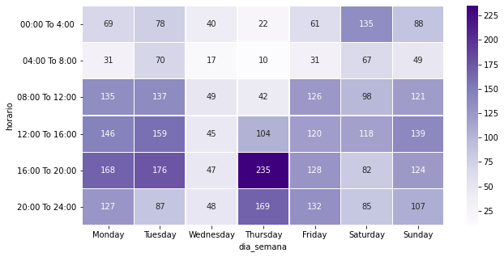

```python
import seaborn as sns
%matplotlib inline

fig, ax = plt.subplots(figsize=(10,5))
sns.heatmap(table, annot=True,linewidths=.5, ax=ax,fmt='',cmap="Purples")
```

Es notorio que el momento optimo para realizar la pauta y llegar a la mayor cantidad de clientes son los **jueves despues de las 4 de la tarde**.

Revisemos si el resultado anterior se debe a un posible evento realizado un jueves lo que pudo haber incrementado la cantidad de usuarios logueados este dia. Para esto revisamos la distribución de la cantidad de usuarios en cada uno de los días de la semana.

|  | month | day | dia_semana | usuarios |
| --- | --- | --- | --- | --- |
| 0 | 01 | 01 | Friday | 7 |
| 1 | 01 | 02 | Saturday | 11 |
| 2 | 01 | 03 | Sunday | 4 |
| 3 | 01 | 04 | Monday | 9 |
| 4 | 01 | 05 | Tuesday | 12 |
| 5 | 01 | 06 | Wednesday | 53 |
| 6 | 01 | 07 | Thursday | 9 |
| 7 | 01 | 08 | Friday | 166 |
| 8 | 01 | 09 | Saturday | 87 |
| 9 | 01 | 10 | Sunday | 60 |

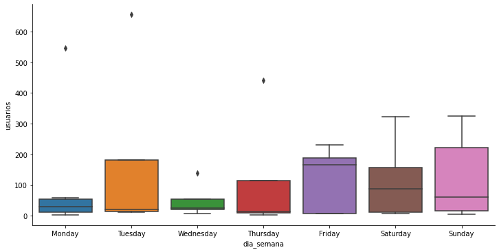

```python
usuarios_dia=data.groupby(['month','day','dia_semana'],as_index=False)["id_usuario"].count().rename(columns={'id_usuario':'usuarios'})\
        .sort_values(['month','day'],ascending=True)
plt.figure(figsize=(20,20))
sb.catplot(x = "dia_semana", y = "usuarios", data = usuarios_dia, kind = "box",aspect = 2,order=['Monday','Tuesday','Wednesday','Thursday','Friday','Saturday','Sunday'])
usuarios_dia.head(10)
```

**Nota** aunque de acuerdo a al resultado anterior se sugiere pautar los jueves en la tarde-noche, no se debería descartar la posibilidad de hacerlo también los viernes ya que es el día que se mantiene más constantemente durante el mes un número importante de clientes conectados. Coje fuerza la hipotesis de que un jueves puntual se realizó un evento.

Por último, identifiquemos la franja horaria en la cual se presenta un mayor número de usuarios.

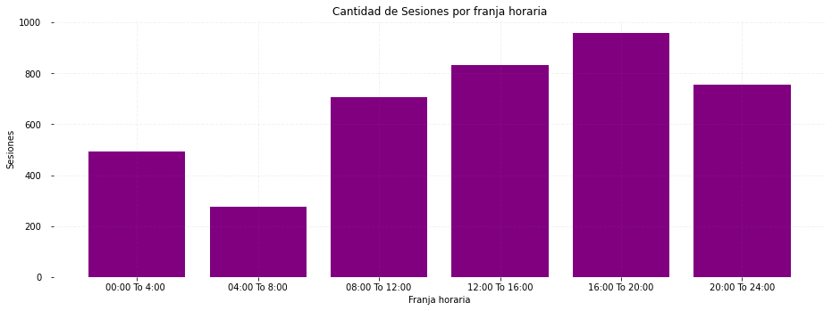

```python
g4=data.groupby(['horario'],as_index=False)["id_usuario"].count().rename(columns={'id_usuario':'Conteo'})\
        .sort_values('horario',ascending=True)

fig = plt.figure()
ax = fig.add_axes([0,0,2,1])
ax.bar(g4["horario"],g4["Conteo"],color='purple')
ax.yaxis.set_tick_params(pad=10)

for s in ['top','bottom','left','right']:
    ax.spines[s].set_visible(False)

# Add x,y gridlines
ax.grid(b=True, color='grey', linestyle='-.', linewidth=0.5, alpha=0.2)

ax.set_title("Cantidad de Sesiones por franja horaria")
ax.set_ylabel("Sesiones")
ax.set_xlabel("Franja horaria")
plt.show()
```

```python
data.groupby(['horario'],as_index=False)["id_usuario"].count().rename(columns={'id_usuario':'Conteo'})\
        .sort_values('horario',ascending=True)
```

|  | horario | Conteo |
| --- | --- | --- |
| 0 | 00:00 To 4:00 | 493 |
| 1 | 04:00 To 8:00 | 275 |
| 2 | 08:00 To 12:00 | 708 |
| 3 | 12:00 To 16:00 | 831 |
| 4 | 16:00 To 20:00 | 960 |
| 5 | 20:00 To 24:00 | 755 |

La gráfica anterior nos permite observar que las mejores franjas horarias para pautar son las tardes y las noches. 4:00 pm a 8:00 pm

## Conclusión

De acuerdo al resultado exploratorio realizado en este documento se puede llegar a la conclusión que el mejor momento para pautar son los **jueves en la tarde-noche (4:00 pm a 8:00 pm)**, tenienendo mayor impacto si se realiza durante los **días 14 y 24** de cada mes.

Otro análisis que se prodría realizar, es identificar si hay edades especificamente que se conectan a cierto horario, pero con la información recolectada no es posible concluir esto.

También sería abueno observar si hay días, dentro de los que se identificaron con alto volumen de información, en los que sea mejor pautar a una franja horaria, así la cantidad de clientes no sea tan elevada si la comparamos con el total general. Esta estrategia depende de la cantidad de pautas que se deseen hacer y en la esperanza de usuarios a los cuales se desee llegar.

La conclusión de este informe es dada suponiendo que se va a realizar una única pauta y se quiere llegar a la mayor cantidad de usuarios posibles.